# Data Summary and Visualization of the MAC PACK ’19

Edwin Reyes Herrera

11/5/2019

```python
from tabulate import tabulate
import pandas as pd
import numpy as np
import seaborn as sns
import matplotlib.pyplot as plt

sns.set(style="whitegrid")
```

```r
library(tidyverse)
library(lubridate)
library(reticulate)
```

The “Mac Pack” is what the Macalester Men’s Cross Country Team is fondly known as, given to our current coach Matt Haugen. He deems the “Mac Pack Era” as the time in which he has been head coach, which has been since the early 2000s. The team nickname is a play-on-words to indicate that we run in packs, which is important in cross country since the goal is to try to minimize the number of points the team collects in a meet.

# Analyzing the 2019 Cross Country Season

This reads in the csv file that was created from the python script dedicated to web scraping meet results and creating a full data frame containing information on all the meets that the men’s cross country team competed in this year. It drops an unused variable left over from that process.

```python
MeetInfo = pd.read_csv("data/MeetTimes_19.csv")
MeetInfo = MeetInfo.drop(['Unnamed: 0'], axis=1)
```

After reading the data frame using python’s `pandas` module, we are able to access it in R using the `reticulate` package and converting some columns into characters, in which Python reads in as a list. Displayed below is the data frame of 2019 results that was scraped from the Python script using `Beautiful Soup`.

```r
MeetInfo <- py$MeetInfo %>%
  mutate_if(is.list,as.character)

MeetInfo
```

| PL | TEAMPLACE | LASTNAME | FIRSTNAME | YEAR | TEAM | Avg. Mile | TIME | SCORE | MEET | DATE | 1K | 2.4K | 4.5K | 7K | 5k | 3K | 5.8K |
| --- | --- | --- | --- | --- | --- | --- | --- | --- | --- | --- | --- | --- | --- | --- | --- | --- | --- |
| 8 | 1 | Lepak | Jake | SR-4 | Macalester | 5:20.6 | 21:22.1 | 8 | Twin Cities Invitational | 2019 | NaN | NaN | NaN | NaN | NaN | NaN | NaN |
| 13 | 2 | Johnson | Adrian | JR-3 | Macalester | 5:25.4 | 21:41.4 | 13 | Twin Cities Invitational | 2019 | NaN | NaN | NaN | NaN | NaN | NaN | NaN |
| 16 | 3 | Hayes | August | FR-1 | Macalester | 5:30.4 | 22:01.4 | 16 | Twin Cities Invitational | 2019 | NaN | NaN | NaN | NaN | NaN | NaN | NaN |
| 17 | 4 | Reyes Herrera | Edwin | SR-4 | Macalester | 5:31.5 | 22:05.9 | 17 | Twin Cities Invitational | 2019 | NaN | NaN | NaN | NaN | NaN | NaN | NaN |
| 19 | 5 | Mayse | Smith | SO-2 | Macalester | 5:31.7 | 22:06.7 | 19 | Twin Cities Invitational | 2019 | NaN | NaN | NaN | NaN | NaN | NaN | NaN |
| 33 | 6 | Kerr | Fred | SO-2 | Macalester | 5:41.2 | 22:44.7 | 32 | Twin Cities Invitational | 2019 | NaN | NaN | NaN | NaN | NaN | NaN | NaN |
| 35 | 7 | O'Donnell-Hoff | Sam | SR-4 | Macalester | 5:42.5 | 22:49.9 | 34 | Twin Cities Invitational | 2019 | NaN | NaN | NaN | NaN | NaN | NaN | NaN |
| 45 | 8 | Milner | Michael | SR-4 | Macalester | 5:48.2 | 23:12.5 | NaN | Twin Cities Invitational | 2019 | NaN | NaN | NaN | NaN | NaN | NaN | NaN |
| 51 | 9 | Peske | Cole | FR-1 | Macalester | 5:52.4 | 23:29.6 | NaN | Twin Cities Invitational | 2019 | NaN | NaN | NaN | NaN | NaN | NaN | NaN |
| 52 | 10 | Hunsanger | Brett | SO-2 | Macalester | 5:52.7 | 23:30.6 | NaN | Twin Cities Invitational | 2019 | NaN | NaN | NaN | NaN | NaN | NaN | NaN |

[output cut: 84 more lines]

Uisng Python’s `seaborn` moduel, we can begon to visualize every runner’s performance throughout the year. Below is a line plot showing the place each runner was on the team for every meet. The lower the place, the faster the athlete ran. We can notice that some athletes only have few data points on their graph - this reflects a missed meet. Looking at my own performance, I can see that I was consistently the same place on the team (4th) for all but one meet.

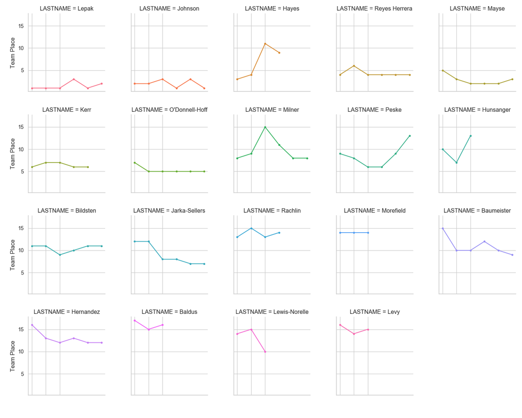

```python
g = sns.FacetGrid(MeetInfo, col="LASTNAME", hue = "LASTNAME", col_wrap=5)
(g.map(plt.plot,"MEET", "TEAMPLACE", marker=".")
.set_axis_labels("", "Team Place")
.set_xticklabels([]))
plt.show()
```

Moreover, we can continue to visualize how each runner performed by plotting every runner’s place on a scatterplot using the meets on the x-axis. In this plot, we can better see how every runner performed relative to all other teammates and also see which runners performed better than others in a given meet. For the most part, we can see those runners that were placed 1st through 5th remained consistent for the entire year, only with some variation. This is neat because it uses `ggplot` to create a visualization from a data frame that was created in Python.

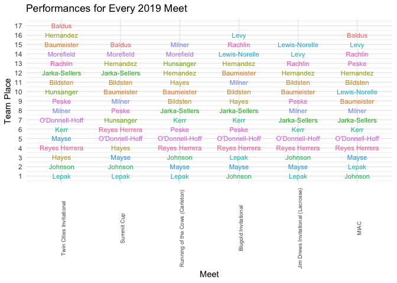

```r
ggplot(MeetInfo, aes(x = MEET, y = TEAMPLACE, label = LASTNAME, color = LASTNAME)) +
    geom_text(size = 3) +
    theme_minimal() +
    theme(axis.text.x=element_text(angle = 90, size = 7), legend.position ="none") +
    labs(x = "Meet", y = "Team Place", title = "Performances for Every 2019 Meet") +
    scale_y_continuous(breaks = seq(1,21, 1)) +
    scale_x_discrete(limits = c("Twin Cities Invitational", "Summit Cup",
                                "Running of the Cows (Carleton)",
                                "Blugold Invitational",
                                "Jim Drews Invitational (Lacrosse)", "MIAC"))
```

```python
# Summarizing the number of meets each runner competed in
runnerMeets = pd.DataFrame(MeetInfo.LASTNAME.value_counts())
runnerMeets.columns = ["Count"]
runnerMeets
```

```
##                 Count
## Milner              6
## O'Donnell-Hoff      6
## Reyes Herrera       6
## Jarka-Sellers       6
## Peske               6
## Bildsten            6
## Baumeister          6
## Johnson             6
## Mayse               6
## Lepak               6
## Hernandez           6
## Kerr                5
## Hayes               4
## Rachlin             4
## Levy                3
## Lewis-Norelle       3
## Morefield           3
## Baldus              3
## Hunsanger           3
```

```python
scorers = list(runnerMeets[runnerMeets.Count == 6].index)
scorers
```

```
## ['Milner', "O'Donnell-Hoff", 'Reyes Herrera', 'Jarka-Sellers', 'Peske', 'Bildsten', 'Baumeister', 'Johnson', 'Mayse', 'Lepak', 'Hernandez']
```

Then, I took the original `MeetInfo` data set that has all the information of 2019 meets and filtered to only reflect runners that were in the top 5 runner for the team in each meet. This reflects those runners that contributed to the overall team score for each meet since only the top 5 runners on each team score. This takes advantage of the `.isin()` function of pandas, which looks to filter the column of `TEAMPLACE` satisfy the condition that it is between 1 and 5.

```python
top5Scores = MeetInfo[MeetInfo.TEAMPLACE.isin(range(1,6))]
top5Scores = top5Scores[top5Scores.LASTNAME.isin(scorers)]
top5Scores = top5Scores.groupby("LASTNAME").sum()[['SCORE']].reset_index()
top5Scores
```

```
##          LASTNAME  SCORE
## 0         Johnson  226.0
## 1           Lepak  216.0
## 2           Mayse  259.0
## 3  O'Donnell-Hoff  392.0
## 4   Reyes Herrera  370.0
```

We can also visualize the summary output above in a barplot. What we can deduce from the summary table and the barplot is that these were the runners that were consistently in the top 5 runners on the team for every meet. It was important to only consider those runners that ran in all meets. This is because if there was a runner that only ran in some meets, and was a scoring runner, then their point accumulation would be lower than everyone else’s.

In addition, we can also see that their total point accumulation reflects what place on the team they usually came in at. What is interesting to note is that the points that Lepak accumulated isn’t that much more less than the points Johnson accumulated. This means that Lepak was not always the number one runner and sometimes placed lower on the team, which contributed to almost having the same total points as Johnson. As such, this plot does a great job of indicating the trajectory of the runners and the place they were on the team. In the end, taking into consideration all meets, Lepak was the number one runner for the 2019 year even if he did have some races where he did not finish number one.

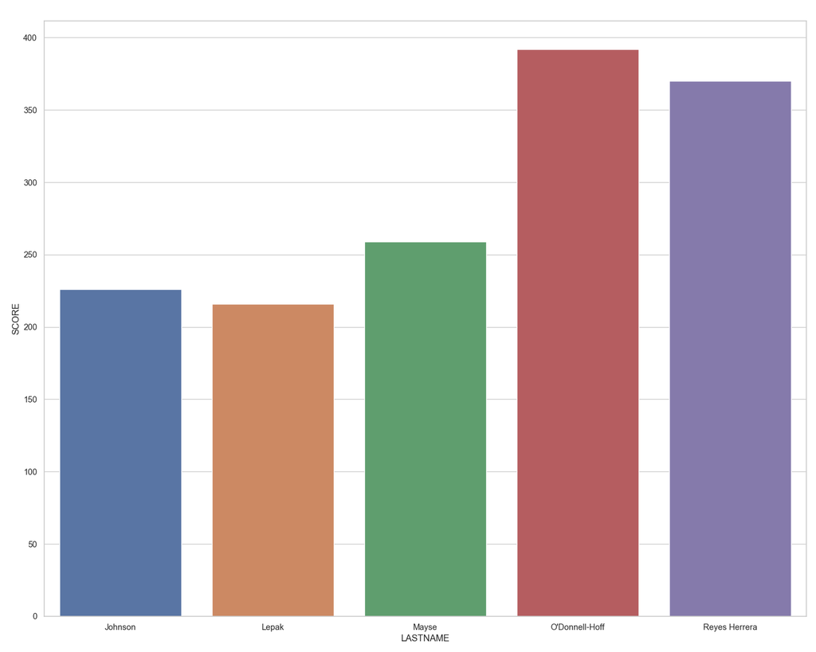

```python
sns.barplot(x="LASTNAME", y="SCORE", data=top5Scores)
```

From there, I was also curious to analyze everyone’s perfromance based on their times for each race. The problem was that when the data was scraped, the times were saved as strings, so there was a need to convert these strings into numeric data. Luckily, R has a package called `lubridate` that is exceptional for working with dates and times.

Using the Python data frame, we update the `MeetInfo` using R and `lubridate` to convert the times reflected in the variables of `TIME` (final time for a meet) and `Avg. Mile` (average mile during a race) from strings to numeric data. We indicate that we want our data to be converted to minutes.

```r
MeetInfo <- MeetInfo %>%
  mutate(TIME = time_length(ms(TIME), unit = "minute"),
         `Avg. Mile` = time_length(ms(`Avg. Mile`), unit = "minute"))

MeetInfo
```

| PL | TEAMPLACE | LASTNAME | FIRSTNAME | YEAR | TEAM | Avg. Mile | TIME | SCORE | MEET | DATE | 1K | 2.4K | 4.5K | 7K | 5k | 3K | 5.8K |
| --- | --- | --- | --- | --- | --- | --- | --- | --- | --- | --- | --- | --- | --- | --- | --- | --- | --- |
| 8 | 1 | Lepak | Jake | SR-4 | Macalester | 5.343333 | 21.36833 | 8 | Twin Cities Invitational | 2019 | NaN | NaN | NaN | NaN | NaN | NaN | NaN |
| 13 | 2 | Johnson | Adrian | JR-3 | Macalester | 5.423333 | 21.69000 | 13 | Twin Cities Invitational | 2019 | NaN | NaN | NaN | NaN | NaN | NaN | NaN |
| 16 | 3 | Hayes | August | FR-1 | Macalester | 5.506667 | 22.02333 | 16 | Twin Cities Invitational | 2019 | NaN | NaN | NaN | NaN | NaN | NaN | NaN |
| 17 | 4 | Reyes Herrera | Edwin | SR-4 | Macalester | 5.525000 | 22.09833 | 17 | Twin Cities Invitational | 2019 | NaN | NaN | NaN | NaN | NaN | NaN | NaN |
| 19 | 5 | Mayse | Smith | SO-2 | Macalester | 5.528333 | 22.11167 | 19 | Twin Cities Invitational | 2019 | NaN | NaN | NaN | NaN | NaN | NaN | NaN |
| 33 | 6 | Kerr | Fred | SO-2 | Macalester | 5.686667 | 22.74500 | 32 | Twin Cities Invitational | 2019 | NaN | NaN | NaN | NaN | NaN | NaN | NaN |
| 35 | 7 | O'Donnell-Hoff | Sam | SR-4 | Macalester | 5.708333 | 22.83167 | 34 | Twin Cities Invitational | 2019 | NaN | NaN | NaN | NaN | NaN | NaN | NaN |
| 45 | 8 | Milner | Michael | SR-4 | Macalester | 5.803333 | 23.20833 | NaN | Twin Cities Invitational | 2019 | NaN | NaN | NaN | NaN | NaN | NaN | NaN |
| 51 | 9 | Peske | Cole | FR-1 | Macalester | 5.873333 | 23.49333 | NaN | Twin Cities Invitational | 2019 | NaN | NaN | NaN | NaN | NaN | NaN | NaN |
| 52 | 10 | Hunsanger | Brett | SO-2 | Macalester | 5.878333 | 23.51000 | NaN | Twin Cities Invitational | 2019 | NaN | NaN | NaN | NaN | NaN | NaN | NaN |

[output cut: 84 more lines]

Using the updated dateframe above, we are able to make a similar line plot to the one above, this time plotting every runner’s trajectory based on their total time for a race. It is important to note that not all races were the same distance - some were only 4 miles, while the typical race is an 8k. To account for this (i.e. avoid any misleading information on the plot when someone’s time suddenly decreases), I ordered the x-axis so as to place those meets that were only 4 miles at the beginning.

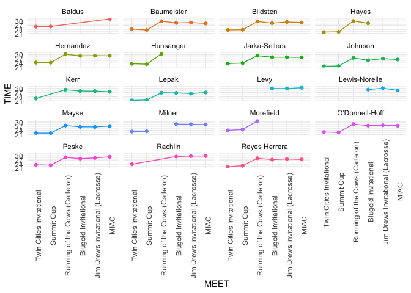

```r
#Visualizing runner performance by final race time for each race
ggplot(MeetInfo, aes(x = MEET, y = TIME, color = LASTNAME, group = LASTNAME)) + geom_point() +
    geom_line() +
    theme_minimal() +
    facet_wrap(vars(LASTNAME), ncol = 4) +
    theme(axis.text.x=element_text(angle = 90), legend.position ="none") +
    scale_x_discrete(limits = c("Twin Cities Invitational", "Summit Cup", "Running of the Cows (Carleton)",
                              "Blugold Invitational", "Jim Drews Invitational (Lacrosse)", "MIAC"))
```

Another way to control for difference in distances for meets is to plot a runner’s trajectory using their average mile pace for a race. In this way, all races are on the same scale and this gives a better perspective on whether a runner ran faster or slower relative to other meets. Looking at my own progression, I generally became faster as the year went on, with a small increase in time in the second and 3rd meets. (Note: the order of the x-axis also reflects the order of meets that we competed in, by chance! So this does in fact show progression throughout the year in chronological order). The absence of dots or breaks in the line show missed meets or DNFs (did not finish).

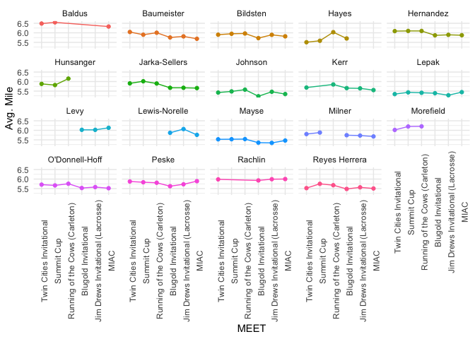

```r
# Visualizing runner performance based on average mile for each race
ggplot(MeetInfo, aes(x = MEET, y = `Avg. Mile`, color = LASTNAME, group = LASTNAME)) + geom_point() +
    geom_line() +
    theme_minimal() +
    facet_wrap(vars(LASTNAME)) +
    theme(axis.text.x=element_text(angle = 90), legend.position ="none") +
    scale_x_discrete(limits = c("Twin Cities Invitational", "Summit Cup", "Running of the Cows (Carleton)","Blugold Invitational", "Jim Drews Invitational (Lacrosse)", "MIAC"))
```

Another neat thing about this analysis is that even though I changed the original data set that was created in Python in R, I am able to return that data frame so that the Python engine can begin using it again, which is what is done below.

Now that we have visualized every runner’s individual performance for the 2019 year, I wanted to analyze the time gap between the first and the 5th runner on the team. Generally, the bigger the gap, the more points that the team accumulates and the worse that the team places overall in a meet.

First, we return the updated data frame of `MeetInfo` into python after manipulating it in Python and assing it to the variable `avgTime` anf filter to only have the top 5 runners for each meet. Then, we group by every meet and use `pandas` `agg()` function to apply three summary statistics for each meet: the fastest time at every meet (min), the slowest time at every meet (max), and the average time at every meet (mean). Then we take advantage of `pandas` `.assign()` function to create a new variable called `gap` that takes the difference in the slowest and fastest time to find the gap in minutes for every meet.

We can observe that the team had the smallest gap between the first and last runner that scored in the Twin Cities Invitational, which was our first race of the year. The gap is about 0.75 minutes, which is about 45 seconds. This is intuitive considering that this was also the meet in which we placed the highest (2nd place overall). This metric, again, controls for the fact that some races were different distances.

```python
avgTime = r.MeetInfo[r.MeetInfo.TEAMPLACE <= 5]
avgTime = pd.DataFrame(avgTime.groupby("MEET").
  agg({"TIME": ["min", "max", "mean"]}).
  rename(columns = {"min":"Time_min", "max":"Time_max", "mean": "AvgTime"}))

avgTimeSummary = avgTime["TIME"].assign(gap = avgTime["TIME"]["Time_max"] - avgTime["TIME"]["Time_min"])

avgTimeSummary = avgTimeSummary.reset_index()
avgTimeSummary
```

```
##                                 MEET   Time_min   Time_max    AvgTime       gap
## 0               Blugold Invitational  26.000000  27.488333  26.827667  1.488333
## 1  Jim Drews Invitational (Lacrosse)  26.266667  27.745000  27.081333  1.478333
## 2                               MIAC  26.571667  27.438333  27.123333  0.866667
## 3     Running of the Cows (Carleton)  26.905000  28.610000  27.801000  1.705000
## 4                         Summit Cup  21.666667  22.550000  22.080000  0.883333
## 5           Twin Cities Invitational  21.368333  22.111667  21.858333  0.743333
```

We can also calculate the average gap between the 1st and 5th runner for the year, which ended up being about 1 minute and 15 seconds.

```python
# Getting average gap between 1st and 5th man for 2019
avgTimeSummary["gap"].mean().round(4)
```

```
## 1.1942
```

# Analyzing the 2016-2019 Seasons

Now that we have analyzed performances for the 2019 cross country season, we can apply the same analysis to *all* races during my four years here at Macalester.

First, we load the data set containing information on all meets for the four years using Python and assign it to `MeetALL`.

```python
MeetALL = pd.read_csv("data/MeetALL.csv")
MeetALL = MeetALL.drop(['Unnamed: 0', 'Unnamed: 0.1'], axis=1)
```

Then we also create it as an R data frame to be able to easily manipulate it.

```r
MeetALL <- py$MeetALL %>%
  mutate_if(is_list, as.character)

MeetALL
```

| PL | TEAMPLACE | LASTNAME | FIRSTNAME | YEAR | TEAM | Avg. Mile | TIME | SCORE | MEET | DATE | 5k | 600m | 1k | 2k | 2.25k | 2.5 Miles | 4.25k | 5.5k | 7k | 7.25k | GAP | Avg. K | 1K | 2.4 | 4.45 | 8k | PACE | 1 Mile | 3300 | … |
| --- | --- | --- | --- | --- | --- | --- | --- | --- | --- | --- | --- | --- | --- | --- | --- | --- | --- | --- | --- | --- | --- | --- | --- | --- | --- | --- | --- | --- | --- | --- |
| 8 | 1 | Hinwood | Lachlan | SR-4 | Macalester | 5:27.0 | 27:05.5 | 7 | River Falls | 2016 | NaN | NaN | NaN | NaN | NaN | NaN | NaN | NaN | NaN | NaN | NaN | NaN | NaN | NaN | NaN | NaN | NaN | NaN | NaN | … |
| 12 | 2 | Grant | Spencer | SO-2 | Macalester | 5:34.5 | 27:42.7 | 11 | River Falls | 2016 | NaN | NaN | NaN | NaN | NaN | NaN | NaN | NaN | NaN | NaN | NaN | NaN | NaN | NaN | NaN | NaN | NaN | NaN | NaN | … |
| 16 | 3 | Harper | Henry | FR-1 | Macalester | 5:35.3 | 27:46.9 | 15 | River Falls | 2016 | NaN | NaN | NaN | NaN | NaN | NaN | NaN | NaN | NaN | NaN | NaN | NaN | NaN | NaN | NaN | NaN | NaN | NaN | NaN | … |
| 19 | 4 | Boranian | Chris | SO-2 | Macalester | 5:37.5 | 27:57.6 | 18 | River Falls | 2016 | NaN | NaN | NaN | NaN | NaN | NaN | NaN | NaN | NaN | NaN | NaN | NaN | NaN | NaN | NaN | NaN | NaN | NaN | NaN | … |
| 24 | 5 | Lepak | Jake | FR-1 | Macalester | 5:39.5 | 28:07.7 | 22 | River Falls | 2016 | NaN | NaN | NaN | NaN | NaN | NaN | NaN | NaN | NaN | NaN | NaN | NaN | NaN | NaN | NaN | NaN | NaN | NaN | NaN | … |
| 39 | 6 | Doherty | James | SO-2 | Macalester | 5:47.5 | 28:47.7 | 36 | River Falls | 2016 | NaN | NaN | NaN | NaN | NaN | NaN | NaN | NaN | NaN | NaN | NaN | NaN | NaN | NaN | NaN | NaN | NaN | NaN | NaN | … |
| 45 | 7 | Richmond | Sam | SO-2 | Macalester | 5:52.5 | 29:12.4 | 42 | River Falls | 2016 | NaN | NaN | NaN | NaN | NaN | NaN | NaN | NaN | NaN | NaN | NaN | NaN | NaN | NaN | NaN | NaN | NaN | NaN | NaN | … |
| 46 | 8 | Engberg | Ethan | SO-2 | Macalester | 5:52.9 | 29:14.2 | NaN | River Falls | 2016 | NaN | NaN | NaN | NaN | NaN | NaN | NaN | NaN | NaN | NaN | NaN | NaN | NaN | NaN | NaN | NaN | NaN | NaN | NaN | … |
| 49 | 9 | Bildsten | Ben | FR-1 | Macalester | 5:53.7 | 29:18.2 | NaN | River Falls | 2016 | NaN | NaN | NaN | NaN | NaN | NaN | NaN | NaN | NaN | NaN | NaN | NaN | NaN | NaN | NaN | NaN | NaN | NaN | NaN | … |
| 54 | 10 | Nelson | Spencer | SR-4 | Macalester | 6:02.1 | 30:00.0 | NaN | River Falls | 2016 | NaN | NaN | NaN | NaN | NaN | NaN | NaN | NaN | NaN | NaN | NaN | NaN | NaN | NaN | NaN | NaN | NaN | NaN | NaN | … |

[output cut: 442 more lines]

Now that it is an R object, we can again use the `lubridate` package to convert the average mile pace and total time for every meet to numeric data on the minutes scale from string objects just as above.

```r
# Converting Time and Average Mile columns to integers using lubridate
MeetALL <- MeetALL %>%
  mutate(TIME = time_length(ms(TIME), unit = "minute"),
         `Avg. Mile` = time_length(ms(`Avg. Mile`), unit = "minute"))
MeetALL
```

| PL | TEAMPLACE | LASTNAME | FIRSTNAME | YEAR | TEAM | Avg. Mile | TIME | SCORE | MEET | DATE | 5k | 600m | 1k | 2k | 2.25k | 2.5 Miles | 4.25k | 5.5k | 7k | 7.25k | GAP | Avg. K | 1K | 2.4 | 4.45 | 8k | PACE | 1 Mile | 3300 | … |
| --- | --- | --- | --- | --- | --- | --- | --- | --- | --- | --- | --- | --- | --- | --- | --- | --- | --- | --- | --- | --- | --- | --- | --- | --- | --- | --- | --- | --- | --- | --- |
| 8 | 1 | Hinwood | Lachlan | SR-4 | Macalester | 5.450000 | 27.09167 | 7 | River Falls | 2016 | NaN | NaN | NaN | NaN | NaN | NaN | NaN | NaN | NaN | NaN | NaN | NaN | NaN | NaN | NaN | NaN | NaN | NaN | NaN | … |
| 12 | 2 | Grant | Spencer | SO-2 | Macalester | 5.575000 | 27.71167 | 11 | River Falls | 2016 | NaN | NaN | NaN | NaN | NaN | NaN | NaN | NaN | NaN | NaN | NaN | NaN | NaN | NaN | NaN | NaN | NaN | NaN | NaN | … |
| 16 | 3 | Harper | Henry | FR-1 | Macalester | 5.588333 | 27.78167 | 15 | River Falls | 2016 | NaN | NaN | NaN | NaN | NaN | NaN | NaN | NaN | NaN | NaN | NaN | NaN | NaN | NaN | NaN | NaN | NaN | NaN | NaN | … |
| 19 | 4 | Boranian | Chris | SO-2 | Macalester | 5.625000 | 27.96000 | 18 | River Falls | 2016 | NaN | NaN | NaN | NaN | NaN | NaN | NaN | NaN | NaN | NaN | NaN | NaN | NaN | NaN | NaN | NaN | NaN | NaN | NaN | … |
| 24 | 5 | Lepak | Jake | FR-1 | Macalester | 5.658333 | 28.12833 | 22 | River Falls | 2016 | NaN | NaN | NaN | NaN | NaN | NaN | NaN | NaN | NaN | NaN | NaN | NaN | NaN | NaN | NaN | NaN | NaN | NaN | NaN | … |
| 39 | 6 | Doherty | James | SO-2 | Macalester | 5.791667 | 28.79500 | 36 | River Falls | 2016 | NaN | NaN | NaN | NaN | NaN | NaN | NaN | NaN | NaN | NaN | NaN | NaN | NaN | NaN | NaN | NaN | NaN | NaN | NaN | … |
| 45 | 7 | Richmond | Sam | SO-2 | Macalester | 5.875000 | 29.20667 | 42 | River Falls | 2016 | NaN | NaN | NaN | NaN | NaN | NaN | NaN | NaN | NaN | NaN | NaN | NaN | NaN | NaN | NaN | NaN | NaN | NaN | NaN | … |
| 46 | 8 | Engberg | Ethan | SO-2 | Macalester | 5.881667 | 29.23667 | NaN | River Falls | 2016 | NaN | NaN | NaN | NaN | NaN | NaN | NaN | NaN | NaN | NaN | NaN | NaN | NaN | NaN | NaN | NaN | NaN | NaN | NaN | … |
| 49 | 9 | Bildsten | Ben | FR-1 | Macalester | 5.895000 | 29.30333 | NaN | River Falls | 2016 | NaN | NaN | NaN | NaN | NaN | NaN | NaN | NaN | NaN | NaN | NaN | NaN | NaN | NaN | NaN | NaN | NaN | NaN | NaN | … |
| 54 | 10 | Nelson | Spencer | SR-4 | Macalester | 6.035000 | 30.00000 | NaN | River Falls | 2016 | NaN | NaN | NaN | NaN | NaN | NaN | NaN | NaN | NaN | NaN | NaN | NaN | NaN | NaN | NaN | NaN | NaN | NaN | NaN | … |

[output cut: 442 more lines]

Then, the updated `MeetALL` data frame is called back into Python, and we find the slowest, fastest, and average time for each meet for every year only for the top 5 runners in each meet, and also calculate the gaps between the first and fifth runner for every meet - this is all saved into `avgTimeSummaryALL`. An additional summary statistic that we will calculate here is the average mile pace for every meet for every year.

```python
# Calling data frame back into python

avgTimeALL = r.MeetALL[r.MeetALL.TEAMPLACE <= 5]
avgTimeALL = pd.DataFrame(avgTimeALL.groupby(["MEET", "DATE"]).agg(
  Time_min = ("TIME", "min"),
  Time_max = ("TIME", "max"),
  Time_avg = ("TIME", "mean"),
  Avgmile = ("Avg. Mile", "mean")).reset_index())

avgTimeSummaryALL = avgTimeALL.assign(
  gap = avgTimeALL["Time_max"] - avgTimeALL["Time_min"]
)

avgTimeSummaryALL
```

```
##                                  MEET    DATE  ...   Avgmile       gap
## 0                       Augsburg Open  2016.0  ...  5.434333  0.366667
## 1                       Augsburg Open  2017.0  ...  5.758667  1.460000
## 2                Blugold Invitational  2016.0  ...  5.482000  1.266667
## 3                Blugold Invitational  2019.0  ...  5.396667  1.488333
## 4                      Central Region  2016.0  ...  5.497000  1.443333
## 5                      Central Region  2017.0  ...  5.451000  1.261667
## 6                      Central Region  2018.0  ...  5.420333  0.960000
## 7                       Falcon Invite  2017.0  ...  5.635667  1.731667
## 8                               Griak  2016.0  ...  5.883000  1.838333
## 9                               Griak  2018.0  ...  5.573000  0.505000
## 10  Jim Drews Invitational (Lacrosse)  2016.0  ...  5.642000  1.911667
## 11  Jim Drews Invitational (Lacrosse)  2017.0  ...  5.520667  1.711667
## 12  Jim Drews Invitational (Lacrosse)  2019.0  ...  5.447000  1.478333
## 13                               MIAC  2016.0  ...  5.569000  1.280000
```

[output cut: 16 more lines]

Now that we have information on all four years, we can determine which Mac Pack team in this four year span was the “best” in terms of gap between the first and last runners who score. We group by year and find the average gap for every meet for every year and visualize the results in a barplot. We can see that during my four years at Macalester, the “best” team was in 2018 with a gap of about 50 seconds, followed by the 2019 team with an average gap of about 1 minute and 15 seconds.

I was wondering which team also contributed the least amount of points throughout the year, but teams were unable to be compared since some teams ran in more meets than others, so the point accumulation would not be representative of performance in this case.

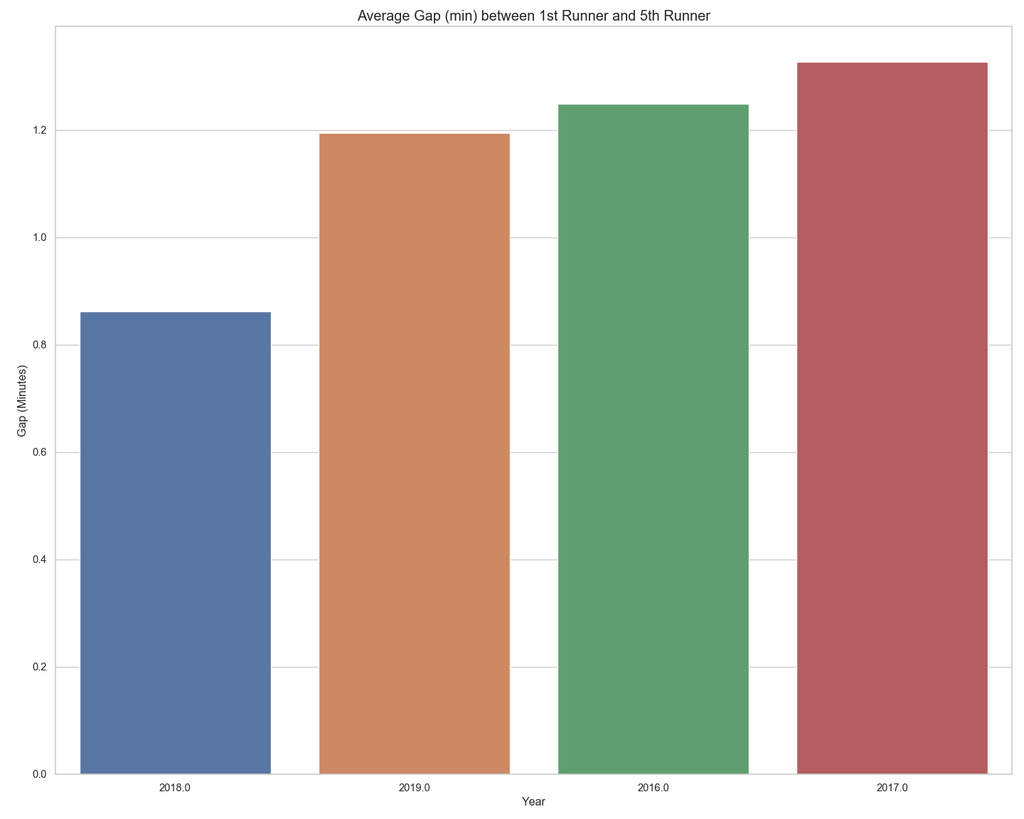

```python
gapsALL = pd.DataFrame(avgTimeSummaryALL.groupby("DATE")
  .mean()["gap"]).reset_index()

plot = sns.barplot(x="DATE", y = "gap", data = gapsALL, order= [2018.0, 2019.0, 2016.0, 2017.0])
plot.set_title("Average Gap (min) between 1st Runner and 5th Runner", fontsize = 15)
plot.set_xlabel("Year")
plot.set_ylabel("Gap (Minutes)")
```

We can also visualize race performance using the data we gathered above on average time and average gap for every meet for every year. The plot below shows the average time for every meet across all four years. Again, those races that were not an 8k distance (now including 4 mile and 5k races) were place at the beginning fo the plot (going left to right) to avoid any misonceptions about the time.

In this plot, we can observe that the 2018 and 2019 years ran less in meets than in 2017 or 2016 teams, which may be a factor in why their gaps were much better. The 2018 team’s times stayed very consistent, while the 2019 team had slightly more variability in times. The second plot communicates the same information except all the years are visualized on the same plot, making it easier for comparison

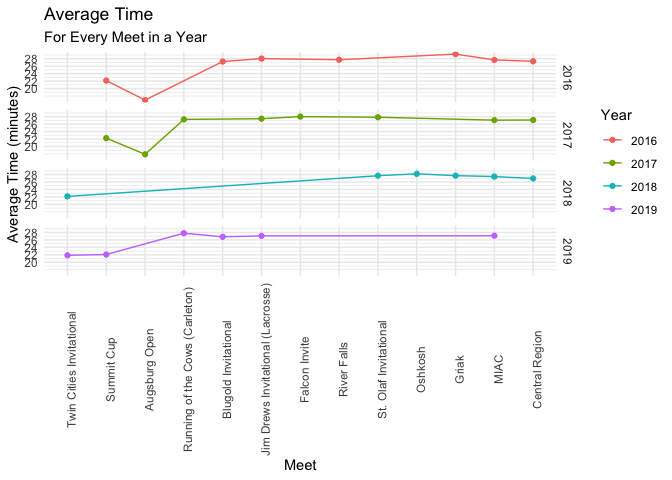

```r
py$avgTimeSummaryALL %>%
  ggplot(aes(x = MEET, y = Time_avg, color = factor(DATE), group = DATE))+
  geom_line() +
  geom_point() +
  facet_grid(rows = vars(DATE)) +
  labs(x = "Meet", y = "Average Time (minutes)", color = "Year", title = "Average Time", subtitle = "For Every Meet in a Year") +
  theme_minimal() +
  theme(axis.text.x = element_text(angle = 90)) +
  scale_y_continuous(breaks = seq(20,32,2)) +
  scale_x_discrete(limits = c("Twin Cities Invitational", "Summit Cup", "Augsburg Open", "Running of the Cows (Carleton)",
                              "Blugold Invitational", "Jim Drews Invitational (Lacrosse)", "Falcon Invite", "River Falls",
                              "St. Olaf Invitational", "Oshkosh", "Griak", "MIAC", "Central Region"))
```

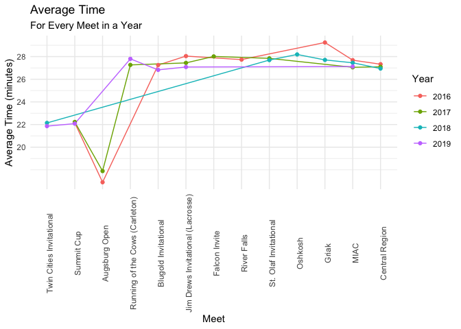

```r
py$avgTimeSummaryALL %>%
  ggplot(aes(x = MEET, y = Time_avg, color = factor(DATE), group = DATE))+
  geom_line() +
  geom_point() +
  labs(x = "Meet", y = "Average Time (minutes)", color = "Year", title = "Average Time", subtitle = "For Every Meet in a Year") +
  theme_minimal() +
  theme(axis.text.x = element_text(angle = 90)) +
  scale_y_continuous(breaks = seq(20,32,2)) +
  scale_x_discrete(limits = c("Twin Cities Invitational", "Summit Cup", "Augsburg Open", "Running of the Cows (Carleton)",
                              "Blugold Invitational", "Jim Drews Invitational (Lacrosse)", "Falcon Invite", "River Falls",
                              "St. Olaf Invitational", "Oshkosh", "Griak", "MIAC", "Central Region"))
```

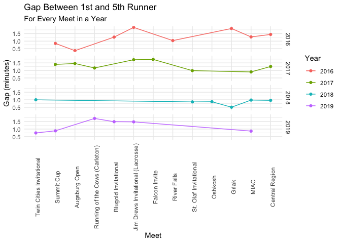

```r
py$avgTimeSummaryALL %>%
  ggplot(aes(x = MEET, y = gap, color = factor(DATE), group = DATE))+
  geom_line() +
  geom_point() +
  facet_grid(rows = vars(DATE), ) +
  labs(x = "Meet", y = "Gap (minutes)", color = "Year", title = "Gap Between 1st and 5th Runner", subtitle = "For Every Meet in a Year") +
  theme_minimal() +
  theme(axis.text.x = element_text(angle = 90)) +
  scale_x_discrete(limits = c("Twin Cities Invitational", "Summit Cup", "Augsburg Open", "Running of the Cows (Carleton)",
                              "Blugold Invitational", "Jim Drews Invitational (Lacrosse)", "Falcon Invite", "River Falls",
                              "St. Olaf Invitational", "Oshkosh", "Griak", "MIAC", "Central Region"))
```

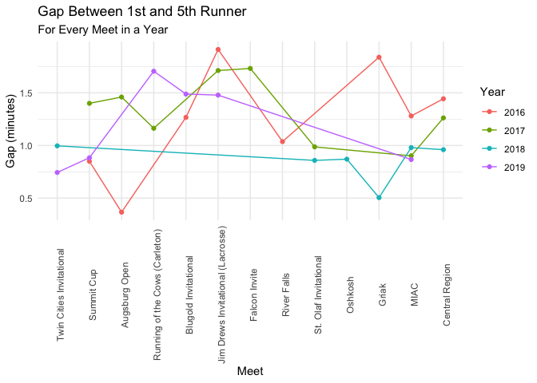

```r
py$avgTimeSummaryALL %>%
  ggplot(aes(x = MEET, y = gap, color = factor(DATE), group = DATE))+
  geom_line() +
  geom_point() +
  labs(x = "Meet", y = "Gap (minutes)", color = "Year", title = "Gap Between 1st and 5th Runner", subtitle = "For Every Meet in a Year") +
  theme_minimal() +
  theme(axis.text.x = element_text(angle = 90)) +
  scale_x_discrete(limits = c("Twin Cities Invitational", "Summit Cup", "Augsburg Open", "Running of the Cows (Carleton)",
                              "Blugold Invitational", "Jim Drews Invitational (Lacrosse)", "Falcon Invite", "River Falls",
                              "St. Olaf Invitational", "Oshkosh", "Griak", "MIAC", "Central Region"))
```

Finally, we can also calculate average mile pace for the scoring runners for every meet for every year in this time span. This again would place all meets on the same scale and would be a better metric to compare performance at every meet for each year.

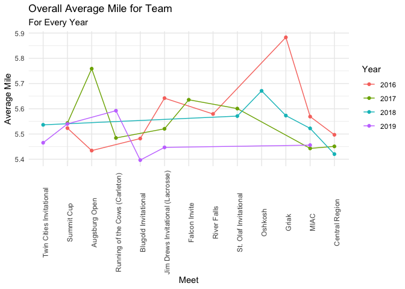

```r
py$avgTimeSummaryALL %>%
  ggplot(aes(x = MEET, y = Avgmile, color = factor(DATE), group = DATE)) +
  geom_line() +
  geom_point() +
  theme_minimal() +
  theme(axis.text.x = element_text(angle = 90)) +
  labs(x = "Meet", y = "Average Mile", color = "Year",
       title = "Overall Average Mile for Team", subtitle = "For Every Year") +
  scale_x_discrete(limits = c("Twin Cities Invitational", "Summit Cup", "Augsburg Open", "Running of the Cows (Carleton)",
                              "Blugold Invitational", "Jim Drews Invitational (Lacrosse)", "Falcon Invite", "River Falls",
                              "St. Olaf Invitational", "Oshkosh", "Griak", "MIAC", "Central Region"))
```

From the plots above, we can see how each team did compared to others for the same meets. As was mentioned before, the 2018 team in general was the “best” in most of the metrics above, though in some other years, the team had a fast average time for a meet or a smaller gap between runners. It is important to take into consideration both gap and overall average mile for the team because a gap between runners can be small, but if they all ran relatively slow, then the point totals would be higher. Similarly, if the average time for a meet was very fast, but the gap was large, then the point total would also be large. As such, we can only deduce from the beginning of this analysis that the team with the smallest gap between runners was the 2018 squad. However, taking into consideration the plots below, we see that the 2019 team had both the fastest average mile and fastest overall average time. Therefore, the 2019 in reality may have been slightly better than the 2018 team, though the 2018 team did have the bets finish in Mac Pack team history, which may have been what gave them the margin in having the best gap. Of course, every team ran in different meets throughout the year and some ran more than others, so some of these comparisons may not be fair. However, this analysis still is able to visualize the team’s trajectory throughout the year.

```python
avgMileALL = pd.DataFrame(avgTimeSummaryALL.groupby("DATE")
  .mean()["Avgmile"]).reset_index()

avgMileALL
```

```
##      DATE   Avgmile
## 0  2016.0  5.576250
## 1  2017.0  5.554667
## 2  2018.0  5.549000
## 3  2019.0  5.482889
```

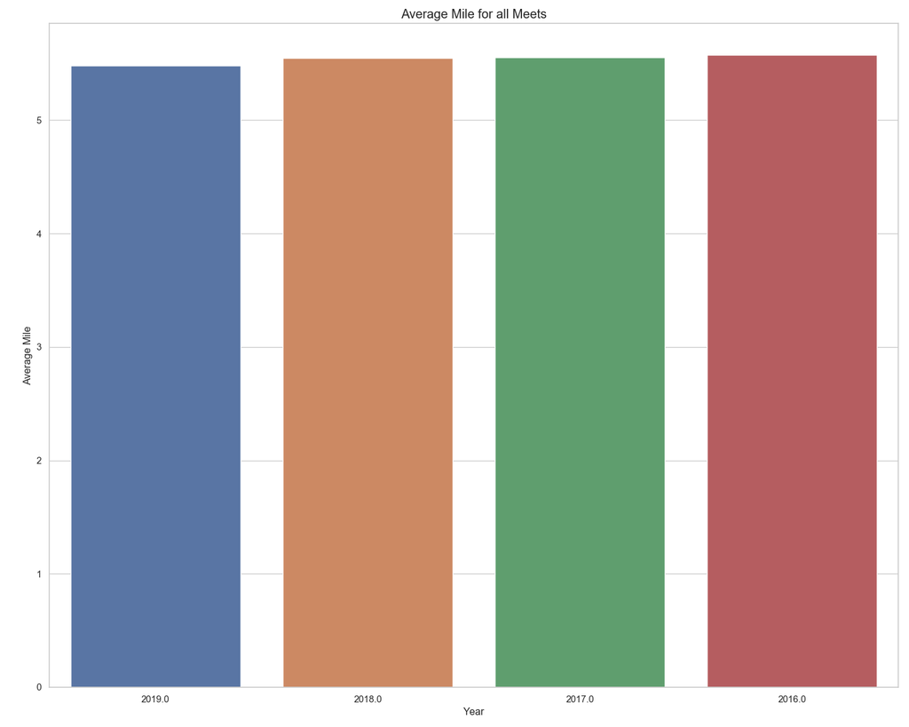

```python
plot = sns.barplot(x="DATE", y = "Avgmile", data = avgMileALL, order= [2019.0, 2018.0, 2017.0, 2016.0])
plot.set_title("Average Mile for all Meets", fontsize = 15)
plot.set_xlabel("Year")
plot.set_ylabel("Average Mile")
```

```python
avgTimeALL = pd.DataFrame(avgTimeSummaryALL.groupby("DATE")
  .mean()["Time_avg"]).reset_index()

avgTimeALL
```

```
##      DATE   Time_avg
## 0  2016.0  25.792833
## 1  2017.0  25.605458
## 2  2018.0  26.689278
## 3  2019.0  25.461944
```

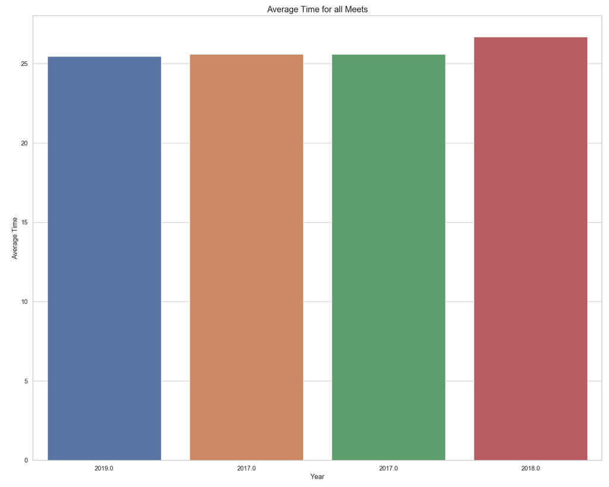

```python
plot = sns.barplot(x="DATE", y = "Time_avg", data = avgTimeALL, order= [2019.0, 2017.0, 2017.0, 2018.0])
plot.set_title("Average Time for all Meets", fontsize = 15)
plot.set_xlabel("Year")
plot.set_ylabel("Average Time")
```

# Analyzing the Class of 2020

A final aspect of this web scraping project I was interested in investigating was visualizing the trajectory of the Class of 2020 teammates during our four years at Macalester. Using Python, I created a list with the remaining Class of 2020 teammates.

```python
class_2020 = ["Reyes Herrera", "Lepak", "Jarka-Sellers", "Milner", "Bildsten", "O'Donnell-Hoff", "Hernandez"]
```

Then using the list above, I filtered the `MeetALL` data from above based on the list above using `.isin()` and saved this new data frame to the `seniors` object.

```python
MeetALL = r.MeetALL

seniors = MeetALL[MeetALL.LASTNAME.isin(class_2020)]
seniors
```

```
##         PL  TEAMPLACE        LASTNAME  ...                7K   3K 5.8K
## 4     24.0        5.0           Lepak  ...               NaN  NaN  NaN
## 8     49.0        9.0        Bildsten  ...               NaN  NaN  NaN
## 12    57.0       13.0  O'Donnell-Hoff  ...               NaN  NaN  NaN
## 15    75.0       16.0       Hernandez  ...               NaN  NaN  NaN
## 24    20.0        6.0           Lepak  ...               NaN  NaN  NaN
## ..     ...        ...             ...  ...               ...  ...  ...
## 440   90.0        5.0  O'Donnell-Hoff  ...  24:03.7 (8:52.0)  NaN  NaN
## 442  123.0        7.0   Jarka-Sellers  ...  24:43.3 (9:04.6)  NaN  NaN
## 443  127.0        8.0          Milner  ...  24:44.1 (9:18.9)  NaN  NaN
## 446  156.0       11.0        Bildsten  ...  25:22.3 (9:29.5)  NaN  NaN
## 447  166.0       12.0       Hernandez  ...  25:42.3 (9:16.9)  NaN  NaN
##
## [148 rows x 43 columns]
```

Now only having information on the Class of 2020, I plotted each of the seven members performances using their final time for every meet between the span of 2016-2019.

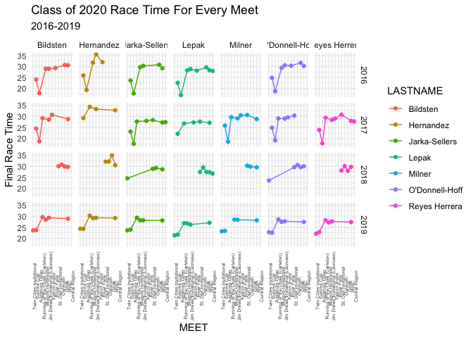

```r
py$seniors %>%
  ggplot(aes(x = MEET, y = TIME, color = LASTNAME, group = LASTNAME)) +
  geom_line() +
  geom_point() +
  facet_grid(rows = vars(DATE), cols = vars(LASTNAME)) +
  theme_minimal() +
  labs(y = "Final Race Time", title = "Class of 2020 Race Time For Every Meet",
       subtitle = "2016-2019") +
  theme(axis.text.x = element_text(angle = 90, size = 5)) +
  scale_x_discrete(limits = c("Twin Cities Invitational", "Summit Cup", "Augsburg Open", "Running of the Cows (Carleton)",
                              "Blugold Invitational", "Jim Drews Invitational (Lacrosse)", "Falcon Invite", "River Falls",
                              "St. Olaf Invitational", "Oshkosh", "Griak", "MIAC", "Central Region"))
```

```python
seniorsAvg = seniors.groupby(["LASTNAME", "DATE"]).mean()["TIME"]
seniorsAvg = seniorsAvg.reset_index()
seniorsAvg
```

```
##           LASTNAME    DATE       TIME
## 0         Bildsten  2016.0  27.226429
## 1         Bildsten  2017.0  26.755833
## 2         Bildsten  2018.0  30.138333
## 3         Bildsten  2019.0  27.273889
## 4        Hernandez  2016.0  28.897000
## 5        Hernandez  2017.0  32.444583
## 6        Hernandez  2018.0  32.475417
## 7        Hernandez  2019.0  27.776944
## 8    Jarka-Sellers  2016.0  26.903889
## 9    Jarka-Sellers  2017.0  25.649762
## 10   Jarka-Sellers  2018.0  27.862500
## 11   Jarka-Sellers  2019.0  26.906944
## 12           Lepak  2016.0  26.353333
## 13           Lepak  2017.0  26.211333
## 14           Lepak  2018.0  27.708667
## 15           Lepak  2019.0  25.011389
## 16          Milner  2017.0  27.594286
## 17          Milner  2018.0  29.928889
## 18          Milner  2019.0  26.373667
## 19  O'Donnell-Hoff  2016.0  27.960476
## 20  O'Donnell-Hoff  2017.0  27.018056
## 21  O'Donnell-Hoff  2018.0  28.701000
## 22  O'Donnell-Hoff  2019.0  26.110556
## 23   Reyes Herrera  2017.0  26.878333
## 24   Reyes Herrera  2018.0  28.997500
## 25   Reyes Herrera  2019.0  25.920000
```

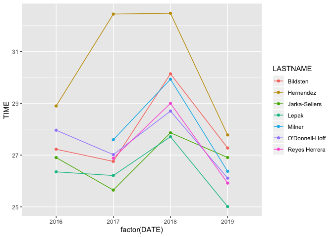

```r
py$seniorsAvg %>%
  ggplot(aes(x = factor(DATE), y = TIME, color = LASTNAME, group = LASTNAME)) +
  geom_line() +
  geom_point()
```

```python
# Filter out non 8k

non8k = ["Summit Cup", "Augsburg Open", "Twin Cities Invitational"]
```

Add column based on conditions in pandas

https://stackoverflow.com/questions/19913659/pandas-conditional-creation-of-a-series-dataframe-column